# Home Work Assignment 6

Anusha Ramamurthy

March 3, 2016

1. Let x denote the sample for an unknown population a.Construct a normal probability plot.

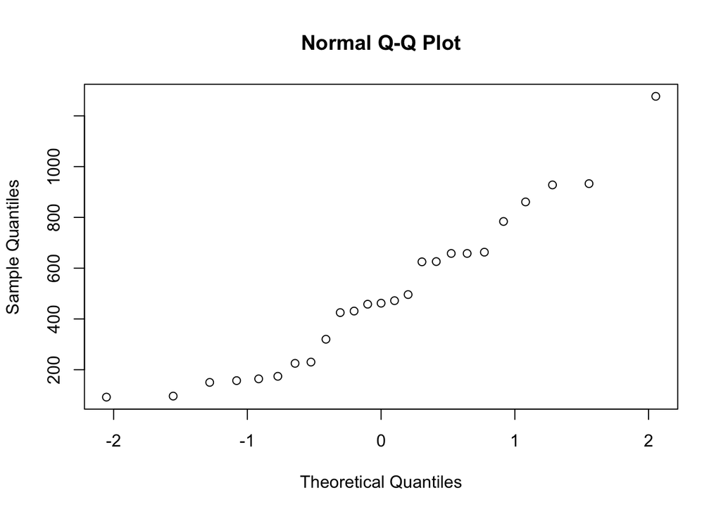

```r
x = c (462,425,164,784,625,472,658,658
       ,663,928,92,230,96,626,1277,225,150,
       320,496,157,458,933,861,174,431)
qqnorm(x)
```

2. Construct the kernel density plot

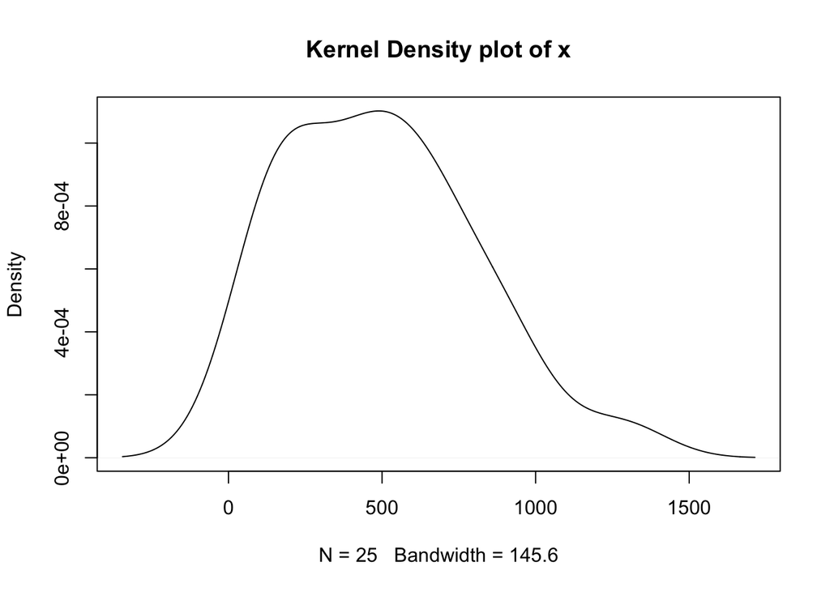

```r
plot(density(x),main="Kernel Density plot of x")
```

3. Do you think this sample was drawn from a normal distribution? Why or why not?

```r
get_iqr = function (s){
q <- as.vector(quantile(s,probs=c(.25,.75)))
iqr <- q[2]-q[1]
return (iqr)
}

get_iqr(x)/sqrt(var(x))
```

```
## [1] 1.405773
```

```r
#for a random sample
xnorm = rnorm(25)
get_iqr(xnorm)/sqrt(var(xnorm))
```

```
## [1] 0.9388596
```

```r
#for binomial sample
xbnom = rbinom(25,15,0.5)
get_iqr(xbnom)/sqrt(var(xbnom))
```

```
## [1] 1.057525
```

```r
#for chi square
xchi = rchisq(25,2)
get_iqr(xchi)/sqrt(var(xchi))
```

```
## [1] 1.293445
```

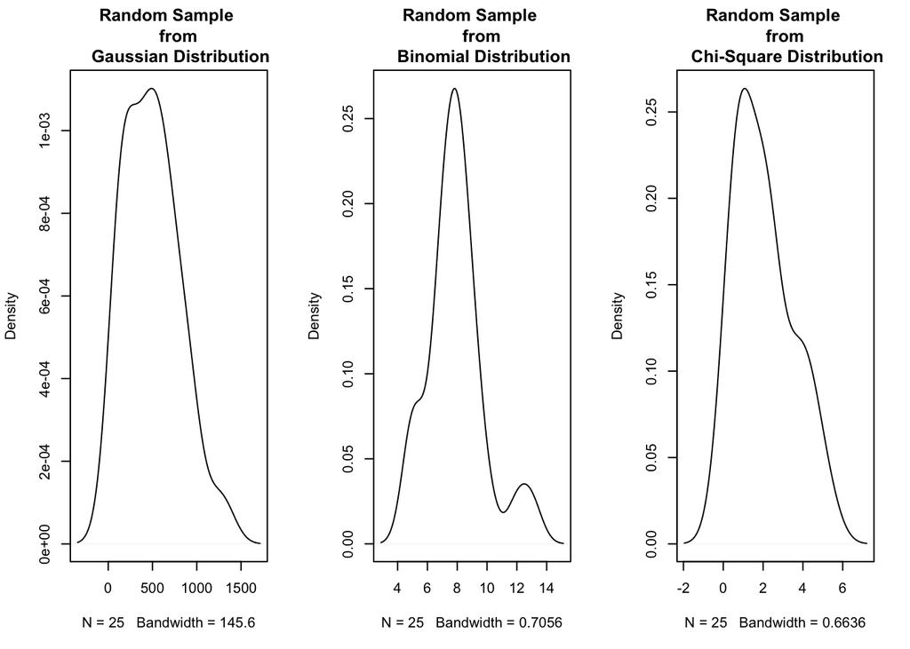

```r
d <- density(x)
d2 <- density(xbnom)
d3 <- density(xchi)
par(mfrow=c(1,3))
plot(d,main="Random Sample
     from
     Gaussian Distribution")
plot(d2,main="Random Sample
     from
     Binomial Distribution")
plot(d3,main="Random Sample
     from
     Chi-Square Distribution")
```

2. The following sample x, was observed and sorted

1. Draw the emprical cumulutive density

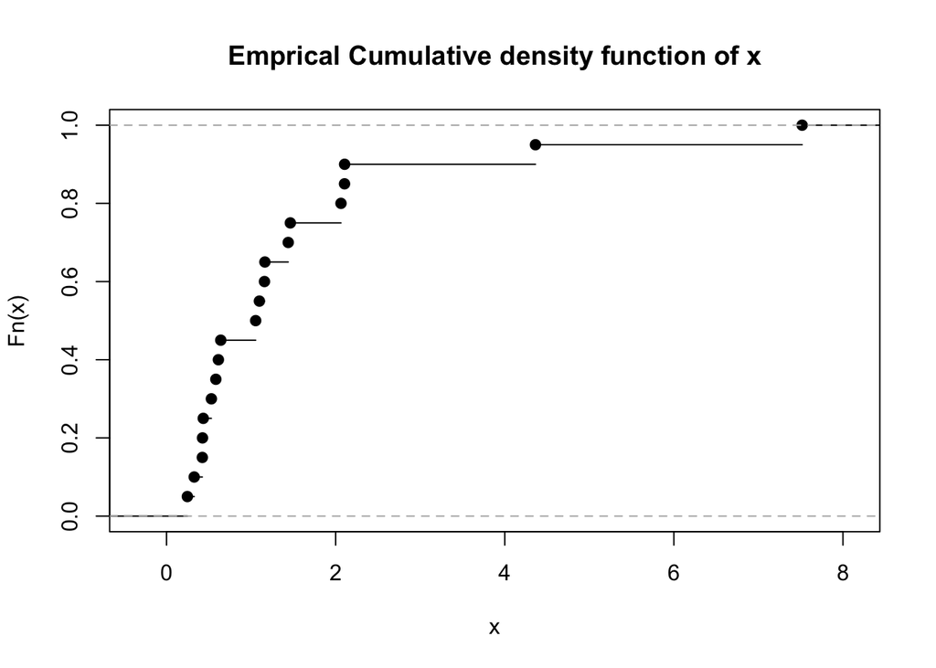

```r
x = c(0.246,0.327,0.423,0.425,0.434 ,0.530,
      0.583,  0.613,  0.641,  1.054, 1.098,  1.158,
      1.163,  1.439,  1.464, 2.063,  2.105,  2.106,
      4.363,  7.517)
plot(ecdf(x),main="Emprical Cumulative density function of x")
```

2. Calculate the plug-in estimates of the mean, the variance, the median, and the interquartile range.

```r
mean(x)
```

```
## [1] 1.4876
```

variance:

```r
var(x)
```

```
## [1] 2.934267
```

median:

```r
median(x)
```

```
## [1] 1.076
```

interquatile range:

```r
get_iqr(x)
```

```
## [1] 1.10775
```

3. Take the square root of the plug-in estimate of the variance and compare it to the plug-in estimate of the interquartile range. Do you think that x was drawn from a normal distribution? Why or why not?

```r
get_iqr(x)/sqrt(var(x))
```

```
## [1] 0.6466837
```

It is not a normal distribution as the ratio of interquartile range to standard deviation is not close to 1.35. The deviation from 1.35 is very large.

However, we see that only for very large sample sizes, will the average ratio be close to 1.35

4. Use the qqnorm function to create a normal probability plot. Do you think that x was drawn from a normal distribution? Why or why not?

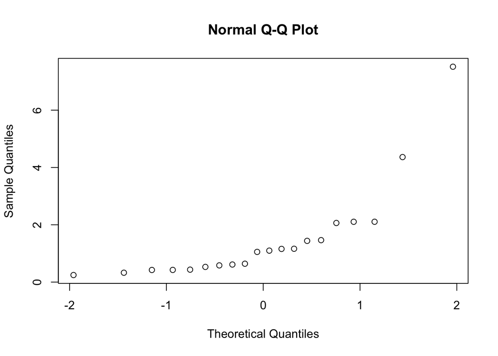

```r
qqnorm(x)
```

The sample doesnt seem to be drawn from a normal distribution, as the values fall below the line.

5. Now consider the transformed sample y produced by replacing each $x_i$ with its natural logarithm. If x is stored in the vector x, then y can be computed by the following R command: Do you think that y was drawn from a normal distribution? Why or why not?

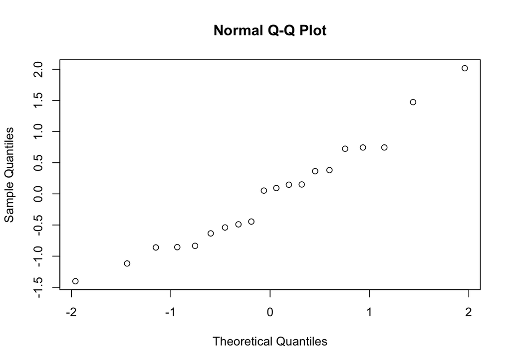

```r
y <- c(log(x))
qqnorm(y)
```

y resembles a normal distribution more so than x. The ratio of square root of the variance of y to its interquartile range is also closer to 1.35 than in the case of x. It is seen that transformations on non normal samples can be normal

```r
get_iqr(y)/sqrt(var(y))
```

```
## [1] 1.308589
```

3. Forty-one students taking Math 351 (Applied Statistics) at the College of William & Mary were administered a test. The following test scores were observed and sorted:

```r
x =c(90,  90,  89,  88,  85,  85,  84,  82,  82,  82,
81,  81,  81,  80,  79,  79,  78,  76,  75,  74, 72,  71,  70,  66,  65,  63,  62,  62,  61,  59, 58,  58,  57,  56,  56,  53,  48,  44,  40,  35,  33)
```

1. Do these numbers appear to be a random sample from a normal distribution?

```r
get_iqr(x)/sd(x)
```

```
## [1] 1.491889
```

1.49 is a large deviation from 1.35, to conclude that x is drawn from a normal distribution.

2. Does this list of numbers have any interesting anomalies?

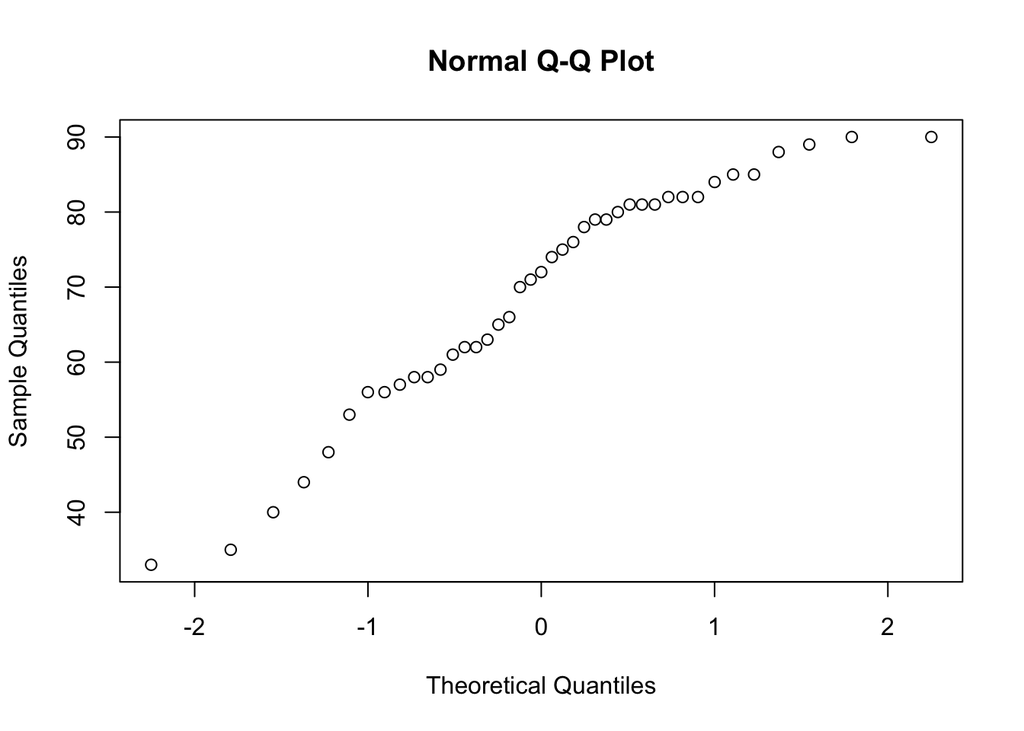

```r
qqnorm(x)
```

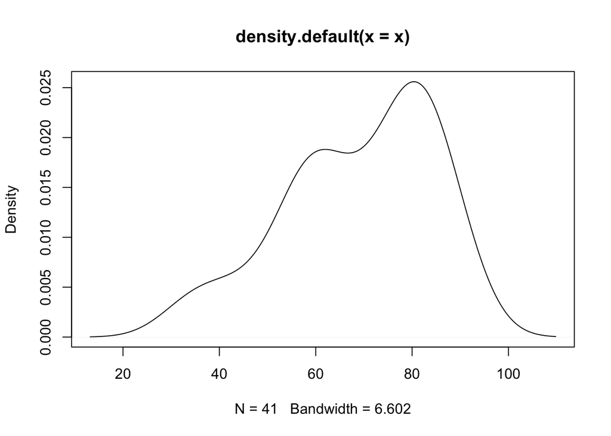

```r
plot(density(x))
```

Answer: We see that the density is left skewed. This is an anomaly since most natural phenomenons occur such that,the probability of larger numbers reduces slowly , unlike here where the probability of large scores occuring increases and then drops abruptly.

4. Chris owns a laser pointer that is powered by two AAAA batteries. A pair of batteries will power the pointer for an average of 5 hours use, with a standard deviation of 30 minutes. Chris decides to take advantage of a sale and buys 20 2-packs of AAAA batteries. What is the probability that he will get to use his laser pointer for at least 105 hours before he needs to buy more batteries?

Answer: By CLT we know that the average of large iid’s follows the normal distribution.

```r
#average pair lasts 5 hrs
mean_sample = 20 * 5
# deviations 30 mins , 0.5 hr
var_sample = (0.5^2) * 20
sd_sample = sqrt(var_sample)
1-pnorm(105,mean_sample,sd_sample)
```

```
## [1] 0.01267366
```

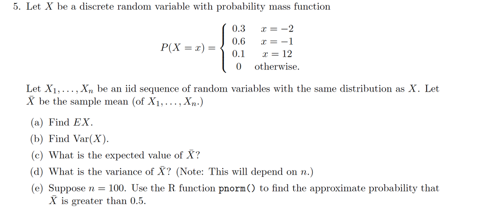

a.

```r
EX = (0.3 * -2) + (0.6 * -1) + (0.1 * 12)
round(EX)
```

```
## [1] 0
```

```r
EX2 = (0.3 * (4)) + (0.6 * (1)) + (0.1 * (144))
varx = EX2 - round(EX)^2
varx
```

```
## [1] 16.2
```

3. same as EX=Zero. As it is uneffected by n
4. variance of average mean = 16.2\ n

```r
sdx = sqrt(varx/100)
1-pnorm(0.5,mean = 0,sdx)
```

```
## [1] 0.1070703
```

6. I want to and out the average number of people per household in the U.S. I survey a simple random sample of U.S. households and obtain the results displayed in the following table. Household size Number of households 1 27 2 34 3 16 4 13 5 6 6 3 7 1
1. Lacking any other information, our best estimate for the population mean household size is the sample mean. What is the sample mean of our data?

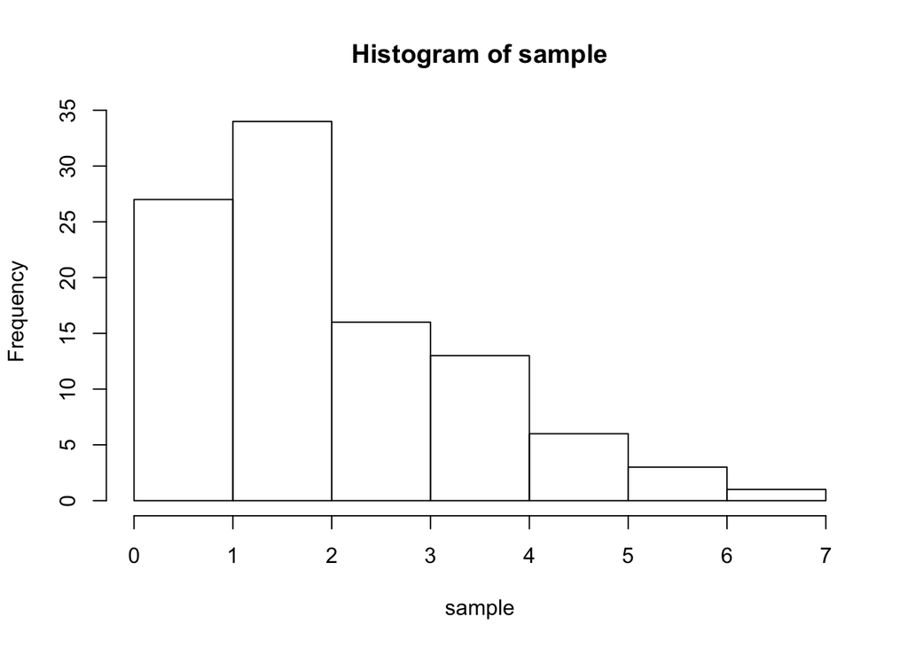

```r
# the number of people  per household results in only one person lives in 27 households, 2 people live in 34 households in the us and so on
sample = c(7,6,6,6,5,5,5,5,5,5,rep(4,13),rep(3,16),rep(2,34),rep(1,27))
hist(sample, breaks = seq(0,7,1))
```

```r
#sample mean is the mean of the distribution
mean(sample)
```

```
## [1] 2.5
```

2. What is our estimate for the standard deviation of household sizes?

```r
sd(sample)
```

```
## [1] 1.410638
```

3. What is the estimated standard error of the sample mean? (That is, based on our answer to (b), what is our estimate for the standard deviation of the distribution of the sample mean?)

```r
#The sample mean deviates from the population mean by 1/sqrt(n)
#n is the number of households
n = 27 + 34 + 16 + 13 + 6 + 3 + 1
sdX_bar_n = sd(sample)/sqrt(100)
sdX_bar_n
```

```
## [1] 0.1410638
```

4. Our error is the difference between the sample mean and the population mean. Using the normal distribution,find the approximate probability that the absolute value of the error in a survey of this form and size is less than 0.5

```r
#error = population mean - sample mean
#find p_hat
zn = 0.5/(1.41/sqrt(100))
pnorm(3.54) - pnorm(-3.54)
```

```
## [1] 0.9995999
```

5. Can we be reasonably sure that the average household size for all U.S. households is between 2 and 3?

Answer: Yes we can be sure that the sample mean that is 2.5 is correct and the average household size will be between 2 and 3 , since the probability that the deviation from this average (of around 0.5) is very close to 1, i.e 0.9995 or 99.95% ```